# Chapter 24 — Practice Challenge Solutions

←Back to the bookChapter 24 · Take the quiz & aim for 100%

Chapter 24 · Solutions

Practice Challenges, Worked Answers ✅

Full solutions to the five "Feature Engineering" challenges. Try them yourself first, then compare.

Statistics, Data Science and AI: A Visual Handbook · John Fisher · 2026

## ⚙️ Setup

```python
import numpy as np
import pandas as pd
from sklearn.preprocessing import OneHotEncoder, OrdinalEncoder, StandardScaler, MinMaxScaler, RobustScaler
from sklearn.compose import ColumnTransformer
from sklearn.model_selection import train_test_split
rng = np.random.default_rng(242)
print("Ready.")
```

```
Ready.
```

CHALLENGE 1 · ONE-HOT A CATEGORY

Nominal to numbers

One-hot encode a 'color' column with get_dummies. How many columns result, and why is one-hot (not integer labels) the right choice for a nominal feature in a linear model?

```python
df = pd.DataFrame({"color": ["red","green","blue","red","green"]})
oh = pd.get_dummies(df["color"], prefix="color").astype(int)
print(oh)
print(f"\n{df['color'].nunique()} categories -> {oh.shape[1]} one-hot columns")
```

```
   color_blue  color_green  color_red
0           0            0          1
1           0            1          0
2           1            0          0
3           0            0          1
4           0            1          0

3 categories -> 3 one-hot columns
```

**Answer:** Three categories become **three 0/1 columns** (`color_blue`, `color_green`, `color_red`). One-hot is correct because color is **nominal**, it has no order. Integer labels (red=0, green=1, blue=2) would tell a linear or distance model that blue is "twice" green and farther from red, a fake ordering. For an unregularized linear model you would also drop one column (`drop_first`) to avoid the dummy-variable trap.

CHALLENGE 2 · ENCODE AN ORDINAL

Keep the real order

A 'rating' column has values Poor, Fair, Good, Excellent. Encode it so the order is preserved, and explain why label-encoding it in alphabetical order would be wrong.

```python
df = pd.DataFrame({"rating": ["Good","Poor","Excellent","Fair","Good"]})
order = ["Poor","Fair","Good","Excellent"]
oe = OrdinalEncoder(categories=[order])
df["code"] = oe.fit_transform(df[["rating"]]).astype(int)
print(df)
```

```
      rating  code
0       Good     2
1       Poor     0
2  Excellent     3
3       Fair     1
4       Good     2
```

**Answer:** Give `OrdinalEncoder` the **explicit order** `["Poor","Fair","Good","Excellent"]` so it maps Poor=0 ... Excellent=3, preserving the real ranking. Letting an encoder assign codes **alphabetically** (Excellent=0, Fair=1, Good=2, Poor=3) would scramble the order, telling the model that "Poor" is the highest rating. For genuinely ordinal data the order is information you must not lose.

CHALLENGE 3 · CHOOSE A SCALER

Resist the outlier

Scale [20, 22, 21, 23, 22, 24, 1000] with StandardScaler, MinMaxScaler, and RobustScaler. Which keeps the six normal values spread out, and why?

```python
x = np.array([20, 22, 21, 23, 22, 24, 1000.0]).reshape(-1,1)
for name, sc in [("Standard",StandardScaler()),("MinMax",MinMaxScaler()),("Robust",RobustScaler())]:
    out = sc.fit_transform(x).ravel()
    print(f"{name:9}: inliers span {out[:-1].max()-out[:-1].min():.3f}, outlier at {out[-1]:.2f}")
```

```
Standard : inliers span 0.012, outlier at 2.45
MinMax   : inliers span 0.004, outlier at 1.00
Robust   : inliers span 2.000, outlier at 489.00
```

**Answer:** **RobustScaler** keeps the six inliers spread out; StandardScaler and especially MinMaxScaler crush them into a tiny range because the 1000 inflates the mean/SD and the max. RobustScaler centers on the **median** and scales by the **IQR**, both unmoved by a single extreme value (Chapter 21), so it is the scaler of choice when outliers are present. (Trees, by contrast, need no scaling at all.)

CHALLENGE 4 · BIN A VARIABLE

Width vs frequency

Bin an income column into 4 groups two ways: equal-width with pd.cut and equal-frequency with pd.qcut. Show the counts per bin and explain the difference.

```python
income = pd.Series([18, 22, 25, 30, 35, 40, 55, 70, 90, 120, 200, 350])
width = pd.cut(income, bins=4)
freq  = pd.qcut(income, q=4)
print("equal-WIDTH (cut):"); print(width.value_counts().sort_index().to_string())
print("\nequal-FREQUENCY (qcut):"); print(freq.value_counts().sort_index().to_string())
```

```
equal-WIDTH (cut):
(17.668, 101.0]    9
(101.0, 184.0]     1
(184.0, 267.0]     1
(267.0, 350.0]     1

equal-FREQUENCY (qcut):
(17.999, 28.75]    3
(28.75, 47.5]      3
(47.5, 97.5]       3
(97.5, 350.0]      3
```

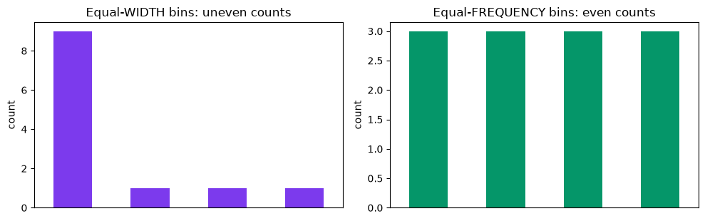

```python
import matplotlib.pyplot as plt
fig, ax = plt.subplots(1, 2, figsize=(10, 3.2))
width.value_counts().sort_index().plot(kind="bar", ax=ax[0], color="#7c3aed"); ax[0].set_title("Equal-WIDTH bins: uneven counts")
freq.value_counts().sort_index().plot(kind="bar", ax=ax[1], color="#059669"); ax[1].set_title("Equal-FREQUENCY bins: even counts")
for a in ax: a.set_xticks([]); a.set_ylabel("count")
plt.tight_layout(); plt.show()
```

**Answer:** `pd.cut(bins=4)` makes **four equal-width** intervals over the range, so the high incomes pile most rows into the lowest bin and leave the top bins nearly empty. `pd.qcut(q=4)` makes **four equal-frequency** bins (quartiles), each with about the same count, but with very different widths. Use width when the scale is meaningful, frequency when you want balanced groups; both lose resolution, which is why modern models often skip binning.

CHALLENGE 5 · BUILD A SAFE TRANSFORMER

No leakage

Build a ColumnTransformer that scales numeric columns and one-hot encodes a categorical column, fit it on a training split, and transform the test split. Why fit on train only?

```python
df = pd.DataFrame({"age": rng.integers(20,60,120), "score": rng.normal(70,10,120), "plan":rng.choice(["A","B","C"],120)})
tr, te = train_test_split(df, test_size=0.3, random_state=1)
ct = ColumnTransformer([
    ("num", StandardScaler(), ["age","score"]),
    ("cat", OneHotEncoder(handle_unknown="ignore", sparse_output=False), ["plan"]),
])
ct.fit(tr)
print("features:", list(ct.get_feature_names_out()))
print(f"train {ct.transform(tr).shape}, test {ct.transform(te).shape}")
```

```
features: ['num__age', 'num__score', 'cat__plan_A', 'cat__plan_B', 'cat__plan_C']
train (84, 5), test (36, 5)
```

**Answer:** The `ColumnTransformer` applies `StandardScaler` to the numeric columns and `OneHotEncoder` to the categorical one in a single object, and `get_feature_names_out()` shows the combined output columns. Fitting on the **training split only** means the scaler's mean/SD and the encoder's category list come from training data, so no information about the test set leaks into the transform. `handle_unknown="ignore"` keeps the test transform working if a category was unseen in training. Wrap the whole thing in a `Pipeline` with a model and the rule holds automatically inside cross-validation.

🎉 Nicely done!

You encoded nominal and ordinal categories correctly, chose an outlier-resistant scaler, binned a variable two ways, and built a leakage-safe transformer. Good features, fit honestly on training data, are what every model downstream is built on.

Statistics, Data Science and AI: A Visual Handbook · © 2026 John Fisher

←Back to the bookChapter 24 · Take the quiz & aim for 100%